# Reproducible Research: Peer Assessment 1

## Background

In recent times, we have seen profileration of the activity monitoring devices, like Fitbit, Nike Fuelband or Jawbone Up. These devices track personal movement at all time. Unfortunately, the utilization of the data has been lacking so far.

In this report, we will review the data from a personal activity device that collects data at 5 minute intervals through out the day. The data consists of two months of data from an anonymous individual collected during the months of October and November, 2012 and include the number of steps taken in 5 minute intervals each day. The raw data and information is based on information from John Hopkins University source.

## Task1 Loading and preprocessing the data

Before we load and process the data, we first clean the environment. Then, we open the data that have been stored in the current working directory.

```r
#clean the environment
rm(list=ls())

#set working directory where the downloaded data is
setwd("~/JHU Data Science/5Reproducible Research/Assignment1/repdata-data-activity")

#load the data
df <- read.csv("activity.csv", stringsAsFactors=FALSE )
```

## Task2 What is mean total number of steps taken per day?

The total number of steps is based on the combined sum of steps for each day. To get these values, we summarized the original raw data to create a daily sum table. As instructed, we ignored the missing values in the dataset.

The data manipulation is done using data.table package.

Based on the summarized data, a histogram of the total number of steps taken each day was constructed.

```r
library(data.table)
df = data.table(df)
df_sum = df[, list(total_steps = sum(steps, na.rm = TRUE)), by = date]

#check the first 3 rows of the daily summary table
head(df_sum,3)
```

```
##          date total_steps
## 1: 2012-10-01           0
## 2: 2012-10-02         126
## 3: 2012-10-03       11352
```

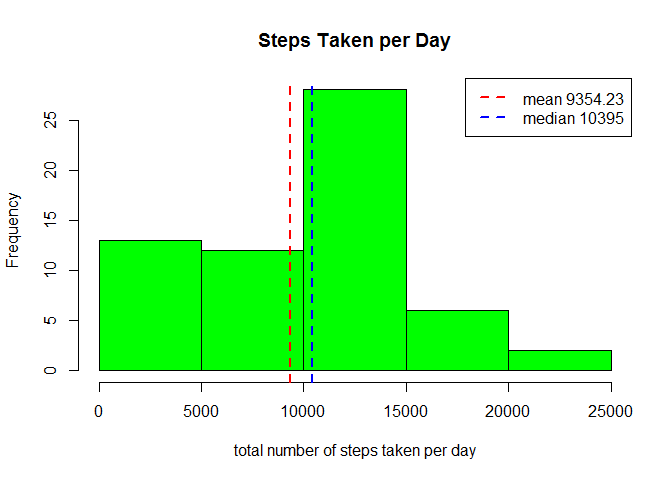

```r
#create histogram
hist(df_sum$total_steps, xlab ="total number of steps taken per day", main ="Steps Taken per Day", col = "green")

#calculate the mean & median
mean_val = round(mean(df_sum$total_steps, na.rm=TRUE),2)
median_val = round(median(df_sum$total_steps, na.rm=TRUE),2)
sd_val = round(sd(df_sum$total_steps, na.rm=TRUE),2)

#create abline for mean & median
abline(v = mean_val, col = "red", lty = 2, lwd = 2 )
abline(v = median_val, col = "blue", lty = 2, lwd = 2 )

#legend text
mean_legend <- paste("mean",mean_val)
median_legend <- paste("median", median_val)

#create legend with the value
legend("topright", col = c("red","blue"), legend = c(mean_legend, median_legend),
      lty = c(2,2), lwd= c(2,2))
```

As can be seen in the histogram, there is also quite a variation of the daily total step count. The standard deviation is 5405.9.

## Task3 What is the average daily activity pattern?

For this task, we look at the data within the day. For each 5 min interval, what the average step is. First, we create a table that summarized the average steps for each interval.

Once again, we ignored the missing value in the datasets. Ignoring the missing value is the same as converting the NA into NULL or 0 values.

To look at the data by interval, we made a time series plot with the x-axis is the 5-minutes interval and the y-axis is the average number of steps taken, averaged across all days.

```r
#summarize table that have the average of steps for each interval. ignore the missing values in the dataset
df_interval = df[, list(avg_steps = mean(steps, na.rm = TRUE)),
                          by = interval]

#check the first 3 rows of the summary table
head(df_interval,3)
```

```
##    interval avg_steps
## 1:        0 1.7169811
## 2:        5 0.3396226
## 3:       10 0.1320755
```

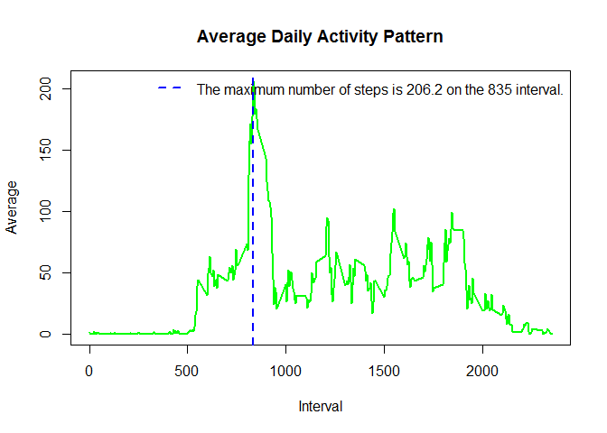

```r
#Make a time series plot (i.e. type = "l") of the 5-minute interval (x-axis) and the average number of steps taken, averaged across all days (y-axis)
with(df_interval,plot(interval,avg_steps, type = "l", xlab="Interval", ylab="Average",
    main = "Average Daily Activity Pattern", col = "green", lwd=2))

#Which 5-minute interval, on average across all the days in the dataset, contains the maximum number of steps?

#find the interval that have the max
max_interval <- df_interval[which.max(avg_steps),]

#create abline for max
abline(v = max_interval$interval, col = "blue", lty = 2, lwd = 2 )

#text for legend
max_string <- paste("The maximum number of steps is",round(max_interval$avg_steps,1),"on the",max_interval$interval,"interval.")
#max_string #check value

#create legend with the value
legend("topright", col = "blue", legend = max_string, lty = 2, lwd= 2, bty = "n")
```

On average, across all the days in the dataset, the interval of 835 contains the maximum number of steps, which is 206.2.

## Task4 Imputing missing values

In the raw data, there were quite a few missing data. This could happened due to measurement or recording error or no activity at all. In the previous assessment, we assumed that all the missing data are due to no activity (0 steps). This assumption possibly caused the mean and median of the total daily steps to be lower than actual.

In this step, we devised another strategy to deal with the missing data. Instead of using 0 value, we now assumed that there is an underlying constant number of steps for each interval. We used the mean for all the interval to replace the NA.

After that, we then created a new table with all the NA have been filled. Then, a histogram with the new data was plotted.

```r
#Calculate and report the total number of missing values in the dataset (i.e. the total number of rows with NAs
summary(df$steps)
```

```
##    Min. 1st Qu.  Median    Mean 3rd Qu.    Max.    NA's
##    0.00    0.00    0.00   37.38   12.00  806.00    2304
```

```r
count_na <- sum(is.na(df$steps))

#copy the original df into new df1
df1 <- df

#The mean of steps in the original data is 37
original_mean <- mean(df$steps, na.rm=TRUE)

#replace steps == NA with 37. Assume that when NA, there is similar steps as the rest.
df1[is.na(df)] <- original_mean

#check whether there is still NA
summary(df1$steps)
```

```
##    Min. 1st Qu.  Median    Mean 3rd Qu.    Max.
##    0.00    0.00    0.00   37.38   37.38  806.00
```

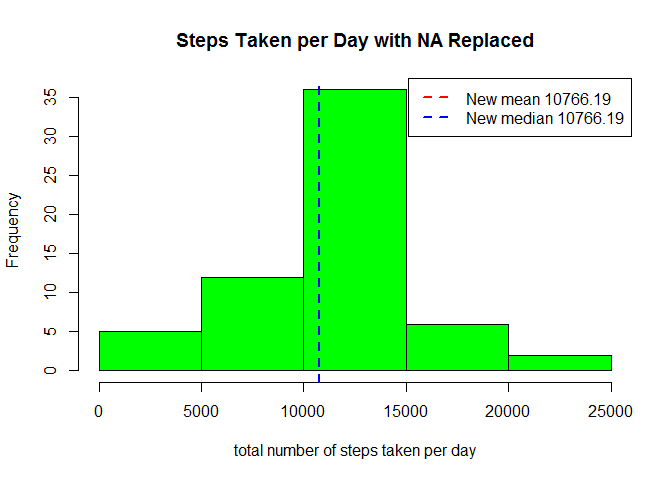

```r
#create new sum table
df_sum1 = df1[, list(total_steps = sum(steps, na.rm = TRUE)), by = date]

#create histogram
hist(df_sum1$total_steps, xlab ="total number of steps taken per day", main ="Steps Taken per Day with NA Replaced", col = "green")

#calculate the mean & median
mean_val1 = round(mean(df_sum1$total_steps),2)
median_val1 = round(median(df_sum1$total_steps),2)

#create abline for mean & median
abline(v = mean_val1, col = "red", lty = 2, lwd = 2 )
abline(v = median_val1, col = "blue", lty = 2, lwd = 2 )

#legend text
mean_legend1 <- paste("New mean",mean_val1)
median_legend1 <- paste("New median", median_val1)

#create legend with the value
legend("topright", col = c("red","blue"), legend = c(mean_legend1, median_legend1),
      lty = c(2,2), lwd= c(2,2))
```

In the original data, there were 2304 NA.

All of these NA were replaced with the mean for all interval, which is 37.4 steps.

The new values differed from the estimates from the first part of assignment. Replacing 0 (ignore NA) with higher number (overall mean) caused higher estimates of the total daily number of steps.

## Task5 Are there differences in activity patterns between weekdays and weekends?

To check whether the steps count change between working days and non-working days, we checked on pattern between weekdays and weekends.

First we created a new variable in the dataset with two levels; “weekday” or “weekend”. This indicated whether a given date is a weekday or weekend day.

Then, we will use this to plot the data with the x-axis is the 5-minute interval and the y-axis is the average number of steps taken. To make it easier to see the difference between weekend and weekdays, we plot the data separately in two panels.

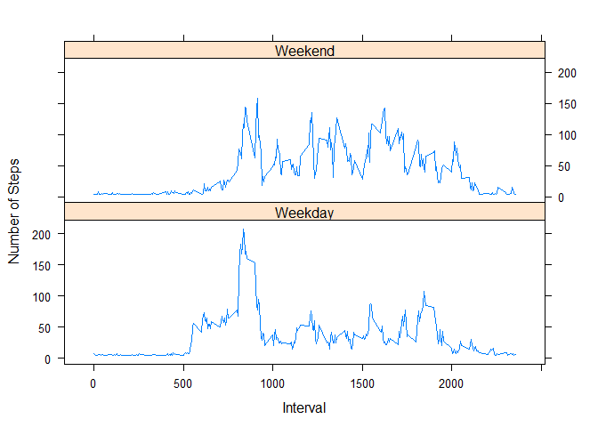

```r
#Make Function To Return Either "Weekday" or "Weekend"
weekpart = function(x){
        if(x %in% c('Saturday', 'Sunday')){
                return('Weekend')
        }

        return('Weekday')
}

#Add Name of Week
df1$dayname = weekdays(as.Date(df$date))

#Add Factor Variable To Differentiate Weekday and Weekend
df1$daytype = as.factor(apply(as.matrix(df1$dayname), 1, weekpart))

#Summarize Dataset: Mean grouped by interval and daytype
df1_day = df1[, list(avg_steps = mean(steps, na.rm = T)),
                          by = list(interval, daytype)]

#make panel plot
library(lattice)
xyplot(avg_steps~interval | daytype, data = df1_day,
      type = 'l',
      xlab = 'Interval',
      ylab = 'Number of Steps',
      layout = c(1,2))
```

In the weekend, there is more constant average number of steps taken throughout the day. In the weekdays, there is a high spike of steps count in the morning, then this taper off the rest of the day.